# Lecture 1 – Data 100, Fall 2020

by Anthony D. Joseph

adapted from Joey Gonzalez, Josh Hug, Suraj Rampure

```python
import pandas as pd
import numpy as np
import matplotlib.pyplot as plt
import seaborn as sns

## Plotly plotting support
import plotly.offline as py
py.init_notebook_mode()
import plotly.graph_objs as go
import plotly.figure_factory as ff
import plotly.express as px
# import cufflinks as cf
# cf.set_config_file(offline=False, world_readable=False, theme='ggplot')
```

### Load and clean the roster

```python
names = pd.read_csv("names.csv")
major_year = pd.read_csv("major_year.csv")[['Majors', 'Terms in Attendance']]
```

```python
names.head(20)
```

|  | Name |
| --- | --- |
| 0 | Gene |
| 1 | Andrew |
| 2 | Michael |
| 3 | Archita |
| 4 | JAKE |
| 5 | Fred |
| 6 | Yash |
| 7 | Lauren |
| 8 | John |
| 9 | Emahn |
| 10 | Charles |
| 11 | Iris |
| 12 | Kseniya |
| 13 | Alex |
| 14 | Justin |
| 15 | Frank |
| 16 | Jaeyun |
| 17 | Andrew |
| 18 | Daisuke |
| 19 | Basil |

```python
names['Name'] = names['Name'].str.lower()
print("Number of Students:", len(names))
names.head(20)
```

```
Number of Students: 1164
```

|  | Name |
| --- | --- |
| 0 | gene |
| 1 | andrew |
| 2 | michael |
| 3 | archita |
| 4 | jake |
| 5 | fred |
| 6 | yash |
| 7 | lauren |
| 8 | john |
| 9 | emahn |
| 10 | charles |
| 11 | iris |
| 12 | kseniya |
| 13 | alex |
| 14 | justin |
| 15 | frank |
| 16 | jaeyun |
| 17 | andrew |
| 18 | daisuke |
| 19 | basil |

```python
names.describe()
```

|  | Name |
| --- | --- |
| count | 1164 |
| unique | 788 |
| top | michael |
| freq | 14 |

```python
major_year["Majors"] = major_year["Majors"].str.replace("BS","").str.replace("BA","")
```

```python
major_year['Terms in Attendance'] = major_year['Terms in Attendance'].astype(str)
```

```python
major_year.head(20)
```

|  | Majors | Terms in Attendance |
| --- | --- | --- |
| 0 | Materials Science & Eng | 5 |
| 1 | Economics , Statistics | 5 |
| 2 | Computer Science | 5 |
| 3 | Computer Science | 7 |
| 4 | Data Science | 5 |
| 5 | Letters & Sci Undeclared UG | 3 |
| 6 | Letters & Sci Undeclared UG | 8 |
| 7 | Business Administration , Electrical Eng & Com... | 3 |
| 8 | Applied Mathematics , Computer Science | 5 |
| 9 | Letters & Sci Undeclared UG | 5 |
| 10 | Cognitive Science | 3 |
| 11 | Data Science | 5 |
| 12 | Letters & Sci Undeclared UG | 5 |
| 13 | Letters & Sci Undeclared UG | 5 |
| 14 | Letters & Sci Undeclared UG | 3 |
| 15 | Applied Mathematics | 6 |
| 16 | Cognitive Science | 7 |
| 17 | Computer Science | 8 |
| 18 | Letters & Sci Undeclared UG | 5 |
| 19 | Bioengineering | 5 |

```python
major_year.describe()
```

|  | Majors | Terms in Attendance |
| --- | --- | --- |
| count | 1164 | 1164 |
| unique | 151 | 8 |
| top | Letters & Sci Undeclared UG | 5 |
| freq | 287 | 505 |

We now know the general structure of our datasets. Let's now ask some questions.

### What is the distribution of the lengths of students' names in this class?

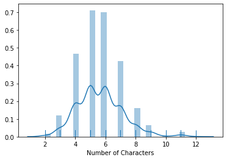

```python
sns.distplot(names['Name'].str.len(), rug=True, axlabel="Number of Characters");
```

### What are the majors of students in the class?

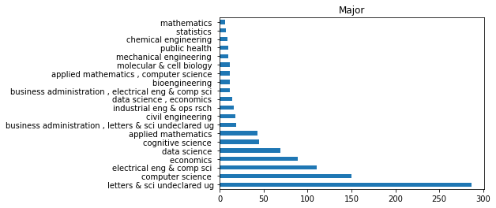

```python
(
    major_year["Majors"]
        .str.lower()
        .value_counts().sort_values(ascending=False)
        .head(20).plot(kind='barh', title = "Major")
);
```

```python
px.bar(major_year['Majors'].value_counts().to_frame().reset_index().head(20),
       x = 'Majors',
       y = 'index',
       orientation = 'h')
```

[interactive chart not shown]

## What is the gender of the class?

How can we answer this question?

```python
print(major_year.columns)
print(names.columns)
```

```
Index(['Majors', 'Terms in Attendance'], dtype='object')
Index(['Name'], dtype='object')
```

#### Ideas:

1. What do we mean by gender?
2. Can we use the name to estimate gender?
3. How would we build model of gender given the name?
4. Where can we get data for such a model?

### US Social Security Data

Public dataset containing baby names and their **sex**.

### Understanding the Setting

**In Data 100 you will have to learn about different data sources on your own.**

[figure not shown]

Reading from [SSN Office description](https://www.ssa.gov/oact/babynames/background.html):

> All names are from Social Security card applications for births that occurred in the United States after 1879. Note that many people born before 1937 never applied for a Social Security card, so their names are not included in our data. For others who did apply, our records may not show the place of birth, and again their names are not included in our data.

> All data are from a 100% sample of our records on Social Security card applications as of March 2017.

### Get data programatically

```python
import urllib.request
import os.path

# Download data from the web directly
data_url = "https://www.ssa.gov/oact/babynames/names.zip"
local_filename = "babynames.zip"
if not os.path.exists(local_filename): # if the data exists don't download again
    with urllib.request.urlopen(data_url) as resp, open(local_filename, 'wb') as f:
        f.write(resp.read())


# Load data without unzipping the file
import zipfile
babynames = []
with zipfile.ZipFile(local_filename, "r") as zf:
    data_files = [f for f in zf.filelist if f.filename[-3:] == "txt"]
    def extract_year_from_filename(fn):
        return int(fn[3:7])
    for f in data_files:
        year = extract_year_from_filename(f.filename)
        with zf.open(f) as fp:
            df = pd.read_csv(fp, names=["Name", "Sex", "Count"])
            df["Year"] = year
            babynames.append(df)
babynames = pd.concat(babynames)


babynames.head()
```

|  | Name | Sex | Count | Year |
| --- | --- | --- | --- | --- |
| 0 | Mary | F | 7065 | 1880 |
| 1 | Anna | F | 2604 | 1880 |
| 2 | Emma | F | 2003 | 1880 |
| 3 | Elizabeth | F | 1939 | 1880 |
| 4 | Minnie | F | 1746 | 1880 |

A little bit of data cleaning:

```python
babynames['Name'] = babynames['Name'].str.lower()
babynames.tail()
```

|  | Name | Sex | Count | Year |
| --- | --- | --- | --- | --- |
| 32028 | zylas | M | 5 | 2018 |
| 32029 | zyran | M | 5 | 2018 |
| 32030 | zyrie | M | 5 | 2018 |
| 32031 | zyron | M | 5 | 2018 |
| 32032 | zzyzx | M | 5 | 2018 |

## Exploratory Data Analysis

How many people does this data represent?

```python
format(babynames['Count'].sum(), ',d')
```

```
'351,653,025'
```

```python
len(babynames)
```

```
1957046
```

**Is this number low or high?**

It seems low. However the social security website states:

```
All names are from Social Security card applications for births that occurred in the United States after 1879. **Note that many people born before 1937 never applied for a Social Security card, so their names are not included in our data.** For others who did apply, our records may not show the place of birth, and again their names are not included in our data. All data are from a 100% sample of our records on Social Security card applications as of the end of February 2016.
```

### Let's query to find rows that match desired conditions.

```python
babynames[(babynames['Name'] == 'vela') & (babynames['Sex'] == 'F')].tail(5)
```

|  | Name | Sex | Count | Year |
| --- | --- | --- | --- | --- |
| 7601 | vela | F | 16 | 2014 |
| 6009 | vela | F | 22 | 2015 |
| 5592 | vela | F | 24 | 2016 |
| 7401 | vela | F | 16 | 2017 |
| 6194 | vela | F | 20 | 2018 |

```python
babynames[(babynames['Name'] == 'anthony') & (babynames['Year'] == 2000)]
```

|  | Name | Sex | Count | Year |
| --- | --- | --- | --- | --- |
| 2781 | anthony | F | 52 | 2000 |
| 17671 | anthony | M | 19651 | 2000 |

```python
babynames.query('Name.str.contains("data")', engine='python')
```

|  | Name | Sex | Count | Year |
| --- | --- | --- | --- | --- |
| 9760 | kidata | F | 5 | 1975 |
| 24915 | datavion | M | 5 | 1995 |
| 23609 | datavious | M | 7 | 1997 |
| 12100 | datavia | F | 7 | 2000 |
| 27502 | datavion | M | 6 | 2001 |
| 28908 | datari | M | 5 | 2001 |
| 29135 | datavian | M | 5 | 2002 |
| 29136 | datavious | M | 5 | 2002 |
| 30570 | datavion | M | 5 | 2004 |
| 17135 | datavia | F | 5 | 2005 |
| 31023 | datavion | M | 5 | 2005 |
| 31019 | datavion | M | 6 | 2006 |
| 33337 | datavious | M | 5 | 2007 |
| 33338 | datavius | M | 5 | 2007 |
| 33397 | datavious | M | 5 | 2008 |
| 33077 | datavion | M | 5 | 2009 |
| 32490 | datavious | M | 5 | 2010 |

### Proportion of Male and Female Individuals Over Time

In this example we construct a **pivot table** which aggregates the number of babies registered for each year by `Sex`.

```python
pivot_year_name_count = pd.pivot_table(babynames,
        index=['Year'], # the row index
        columns=['Sex'], # the column values
        values='Count', # the field(s) to processed in each group
        aggfunc=np.sum,
    )

pivot_year_name_count.head()
```

| Sex Year | F | M |
| --- | --- | --- |
| 1880 | 90994 | 110490 |
| 1881 | 91953 | 100743 |
| 1882 | 107847 | 113686 |
| 1883 | 112319 | 104625 |
| 1884 | 129019 | 114442 |

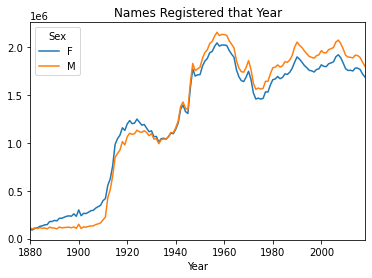

```python
pivot_year_name_count.plot(title='Names Registered that Year');
```

```python
fig = go.Figure()
fig.add_trace(go.Scatter(x = pivot_year_name_count.index, y = pivot_year_name_count['F'], name = 'F', line=dict(color='gold')))
fig.add_trace(go.Scatter(x = pivot_year_name_count.index, y = pivot_year_name_count['M'], name = 'M', line=dict(color='blue')))
fig.update_layout(xaxis_title = 'Year', yaxis_title = 'Names Registered')
```

[interactive chart not shown]

### How many unique names for each year?

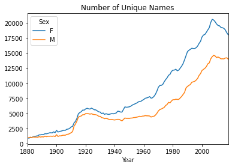

```python
pivot_year_name_nunique = pd.pivot_table(babynames,
        index=['Year'],
        columns=['Sex'],
        values='Name',
        aggfunc=lambda x: len(np.unique(x)),
    )

pivot_year_name_nunique.plot(
   title='Number of Unique Names');
```

**Some observations:**

1. Registration data seems limited in the early 1900s. Because many people did not register before 1937.
2. You can see the [baby boomers](https://www.wikiwand.com/en/Baby_boomers) and the echo boom.
3. Females have greater diversity of names.

## Computing the Proportion of Female Babies For Each Name

```python
sex_counts = pd.pivot_table(babynames, index='Name', columns='Sex', values='Count',
                            aggfunc='sum', fill_value=0., margins=True)
sex_counts.head()
```

| Sex Name | F | M | All |
| --- | --- | --- | --- |
| aaban | 0 | 114 | 114 |
| aabha | 35 | 0 | 35 |
| aabid | 0 | 16 | 16 |
| aabidah | 5 | 0 | 5 |
| aabir | 0 | 10 | 10 |

Compute proportion of female babies given each name.

```python
prop_female = sex_counts['F'] / sex_counts['All']
prop_female.head(10)
```

```
Name
aaban        0.0
aabha        1.0
aabid        0.0
aabidah      1.0
aabir        0.0
aabriella    1.0
aada         1.0
aadam        0.0
aadan        0.0
aadarsh      0.0
dtype: float64
```

```python
prop_female.tail(10)
```

```
Name
zytavion     0.000000
zytavious    0.000000
zyus         0.000000
zyva         1.000000
zyvion       0.000000
zyvon        0.000000
zyyanna      1.000000
zyyon        0.000000
zzyzx        0.000000
All          0.495031
dtype: float64
```

### Testing a few names

```python
prop_female['audi']
```

```
0.6
```

```python
prop_female['anthony']
```

```
0.004882192670149836
```

```python
prop_female['joey']
```

```
0.11189110521359473
```

```python
prop_female['avery']
```

```
0.6934594472508525
```

```python
prop_female["sarah"]
```

```
0.9969234241567629
```

```python
prop_female["min"]
```

```
0.37598736176935227
```

```python
prop_female["pat"]
```

```
0.6001585544619619
```

### Build Simple Classifier (Model)

We can define a function to return the most likely `Sex` for a name. If there is an exact tie, the function returns Male. If the name does not appear in the social security dataset, we return Unknown.

```python
def sex_from_name(name):
    lower_name = name.lower()
    if lower_name in prop_female.index:
        return 'F' if prop_female[lower_name] > 0.5 else 'M'
    else:
        return "Unknown"
```

```python
sex_from_name("audi")
```

```
'F'
```

```python
sex_from_name("joey")
```

```
'M'
```

### What fraction of students in Data 100 this semester have names in the SSN dataset?

```python
student_names = pd.Index(names["Name"]).intersection(prop_female.index)
print("Fraction of names in the babynames data:" , len(student_names) / len(names))
```

```
Fraction of names in the babynames data: 0.8685567010309279
```

### Which names are not in the dataset?

Why might these names not appear?

```python
missing_names = pd.Index(names["Name"]).difference(prop_female.index)
missing_names
```

```
Index(['adithyan', 'air', 'ameek', 'amritansh', 'amrut', 'angikaar', 'anjing',
       'arhubur', 'armyben', 'atte',
       ...
       'yuqi', 'yuxiao', 'zetian', 'zhaotian', 'zhe', 'zhenyi', 'zhijian',
       'zhiping', 'zhiying', 'ziming'],
      dtype='object', name='Name', length=152)
```

## Estimating the fraction of female and male students

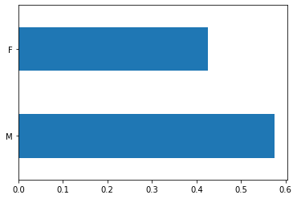

```python
names['Pred. Sex'] = names['Name'].apply(sex_from_name)
(names[names['Pred. Sex'] != "Unknown"]['Pred. Sex'].value_counts()/len(names[names['Pred. Sex'] != "Unknown"])).plot(kind="barh");
```

### Using simulation to estimate uncertainty

Previously we treated a name which is given to females 40% of the time as a "Male" name. This doesn't capture our uncertainty. We can use simulation to provide a better distributional estimate.

### Restricting our attention to students in the class

```python
len(prop_female)
```

```
98401
```

```python
ds100_prob_female = prop_female.loc[prop_female.index.intersection(names['Name'])]
ds100_prob_female.tail(20)
```

```
Name
yash         0.000000
ye           0.421053
yifan        0.117647
yifei        1.000000
yiming       0.000000
yohaan       0.000000
yong         0.289044
yoon         0.266055
yuan         0.159091
yuchen       0.219512
yuxuan       0.372093
zach         0.000000
zachary      0.002828
zack         0.000000
zain         0.036658
zechariah    0.001364
zehra        1.000000
zi           0.508197
zijun        0.000000
zizi         1.000000
dtype: float64
```

### Running the simulation

```python
one_simulation = np.random.rand(len(ds100_prob_female)) < ds100_prob_female
one_simulation.tail(20)
```

```
Name
yash         False
ye            True
yifan        False
yifei         True
yiming       False
yohaan       False
yong          True
yoon         False
yuan         False
yuchen        True
yuxuan        True
zach         False
zachary      False
zack         False
zain         False
zechariah    False
zehra         True
zi            True
zijun        False
zizi          True
dtype: bool
```

```python
# function that performs many simulations
def simulate_class(students):
    is_female = np.random.rand(len(ds100_prob_female)) < ds100_prob_female
    return np.mean(is_female)

fraction_female_simulations = np.array([simulate_class(names) for n in range(10000)])
```

```python
# plt.hist(fraction_female_simulations, bins=np.arange(0.4, 0.46, 0.0025), ec='w');
# pd.Series(fraction_female_simulations).iplot(kind="hist", bins=30)
ff.create_distplot([fraction_female_simulations], ['Fraction Female'], bin_size=0.0025, show_rug=False)
```

[interactive chart not shown]